# Binary Classification Model for Online News Popularity Using R Take 1

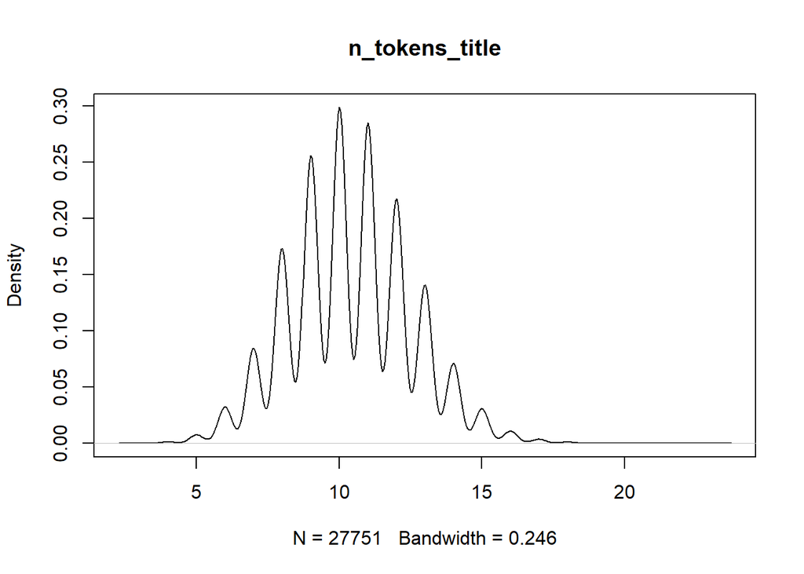

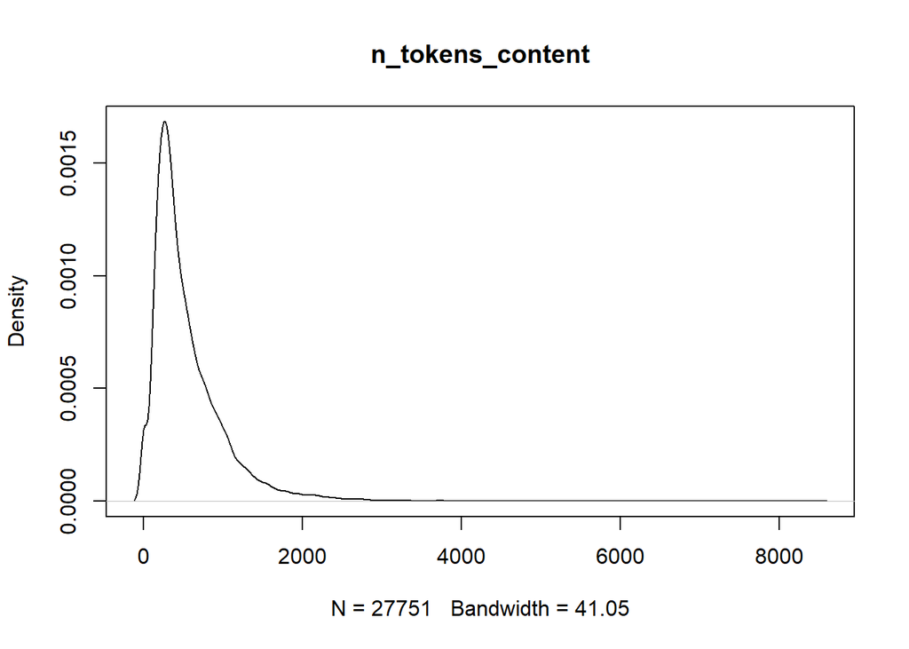

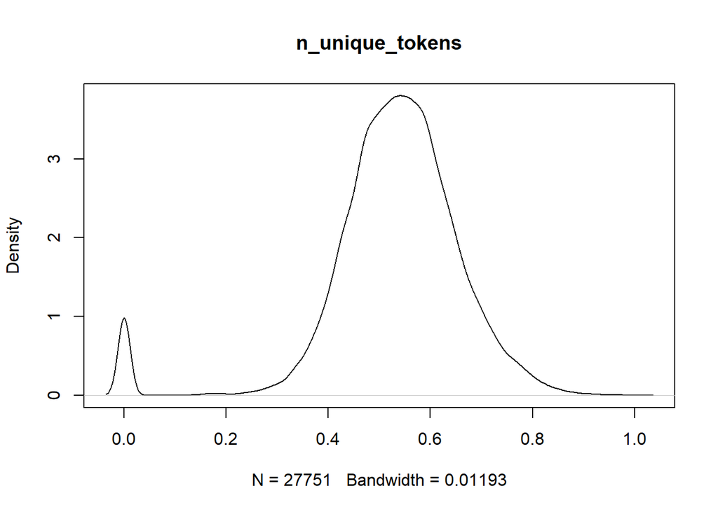

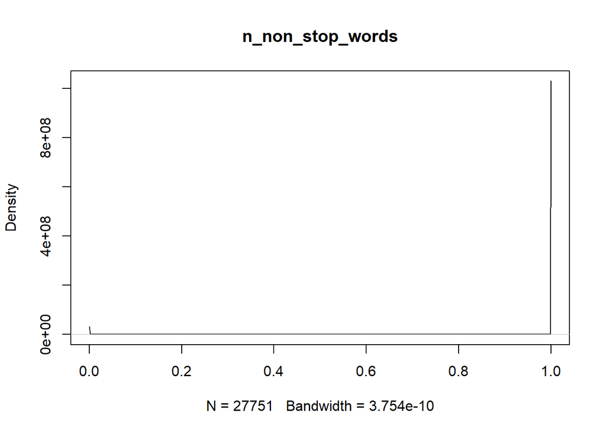

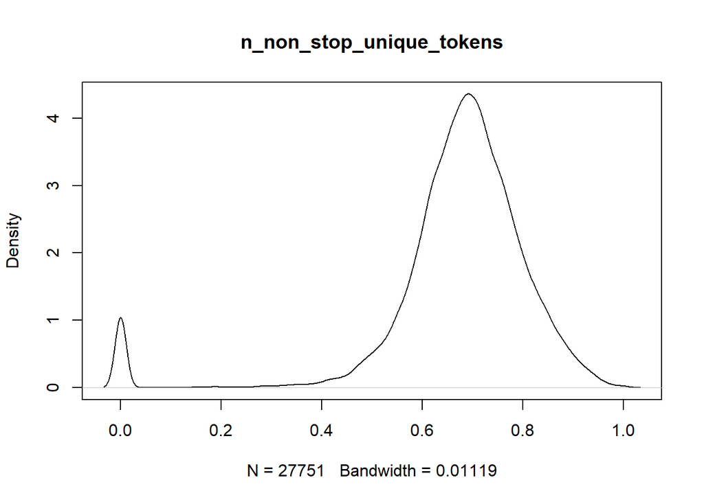

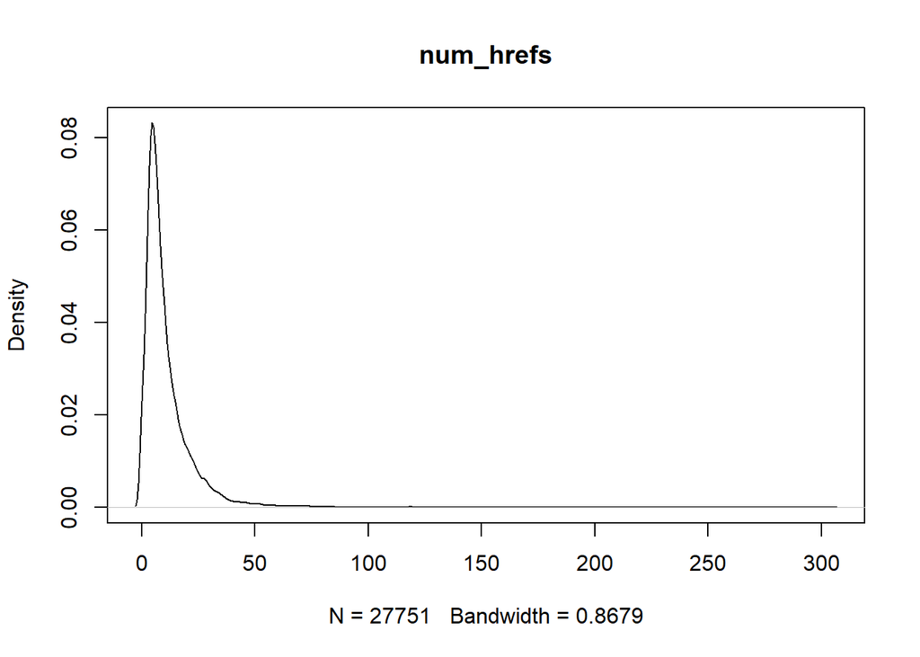

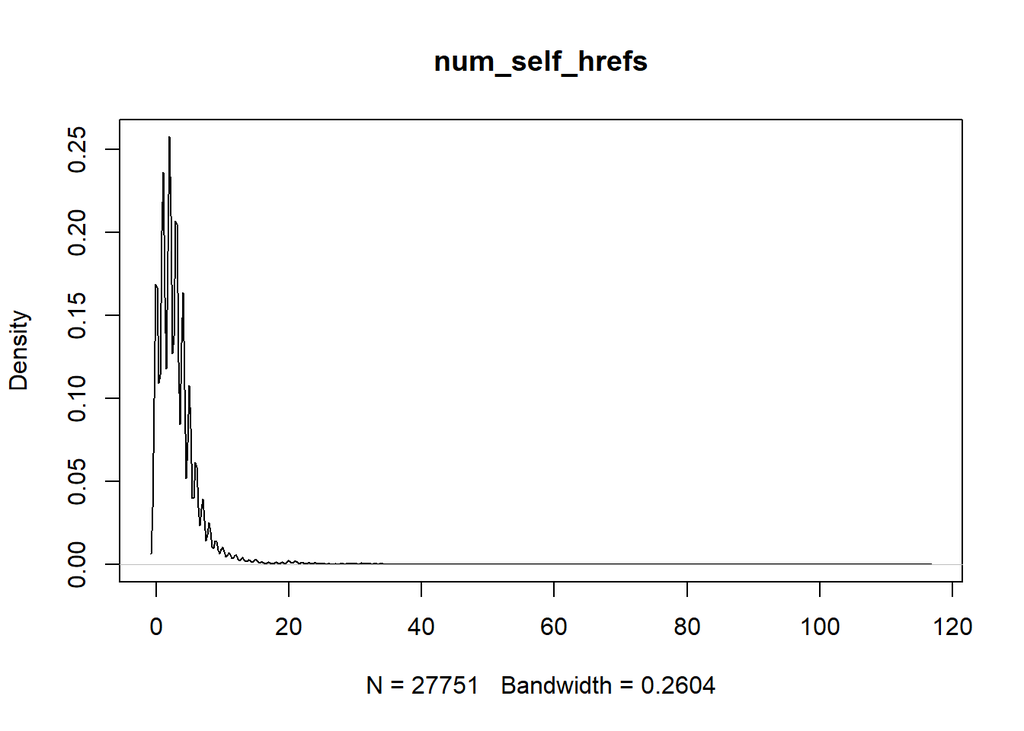

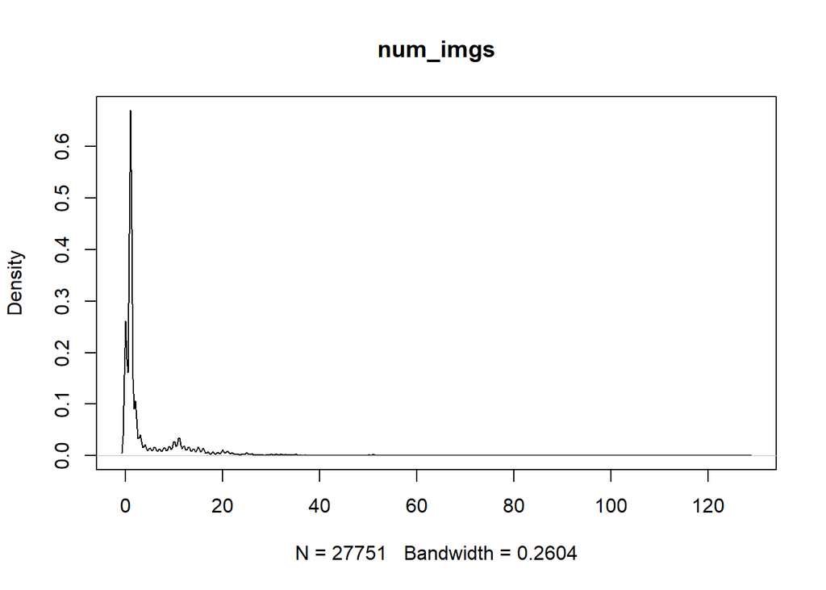

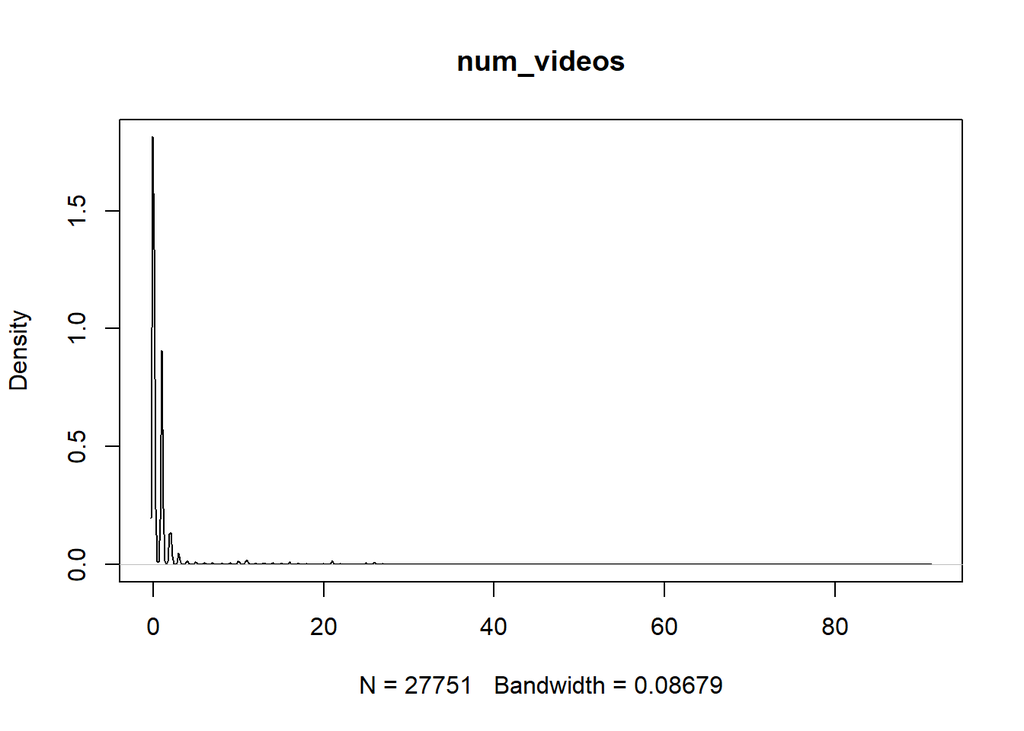

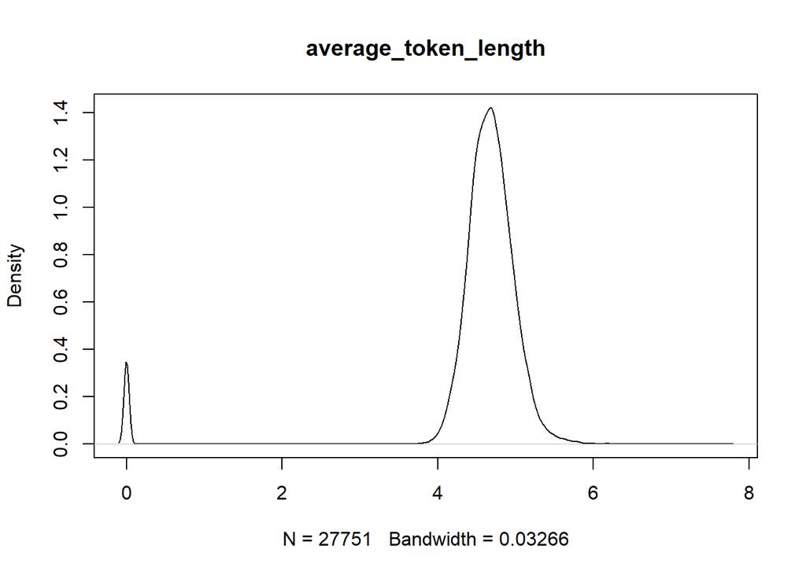

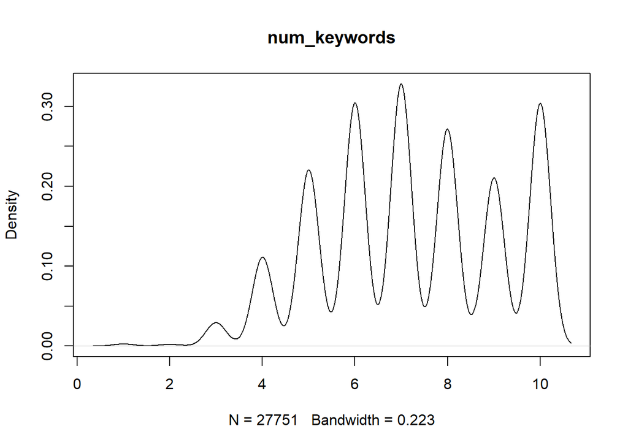

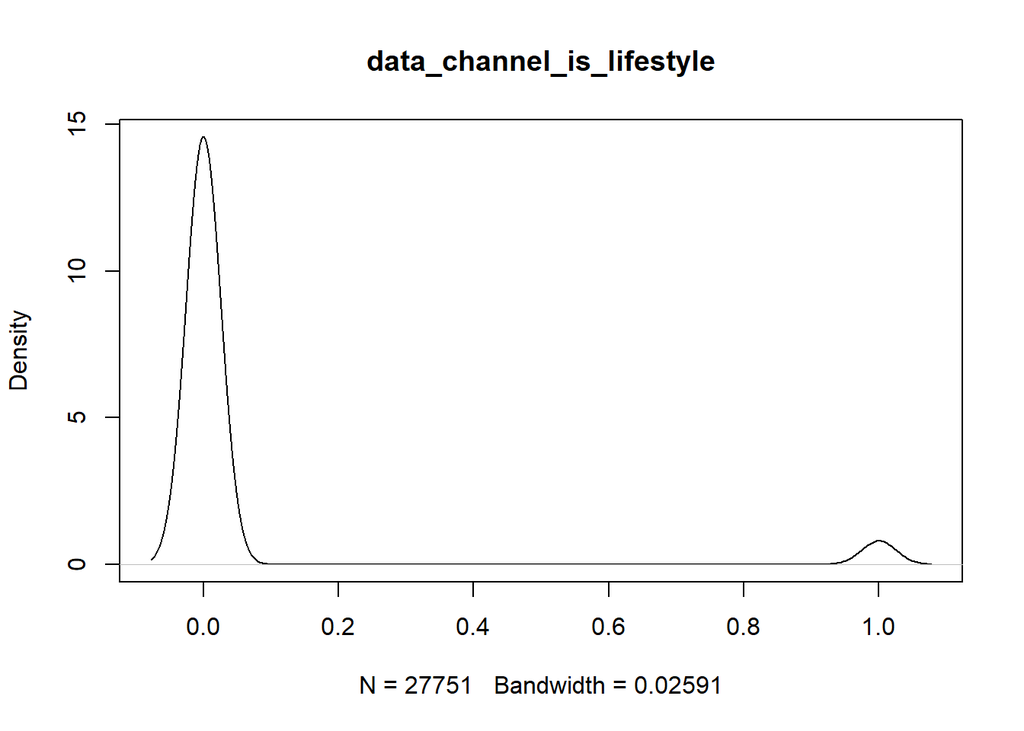

[46 more figures not shown]

```r
# Density plot for each attribute
# par(mfrow=c(dispRow,dispCol))
for(i in 1:totAttr) {
    plot(density(x_train[,i]), main=names(x_train)[i])
}
```

#### 2.b.ii) Multivariate plots to better understand the relationships between attributes

```r
# Scatterplot matrix colored by class
# pairs(targetVar~., data=xy_train, col=xy_train$targetVar)
```

```r
# Box and whisker plots for each attribute by class
# scales <- list(x=list(relation="free"), y=list(relation="free"))
# featurePlot(x=x_train, y=y_train, plot="box", scales=scales)
```

```r
# Density plots for each attribute by class value
# featurePlot(x=x_train, y=y_train, plot="density", scales=scales)
```

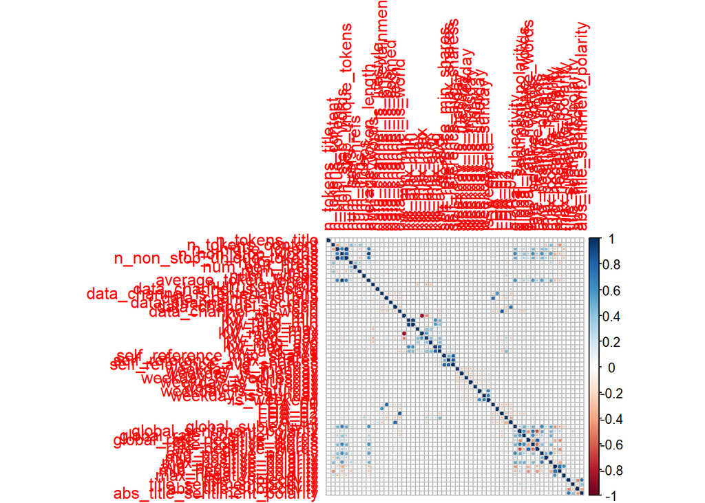

```r
# Correlation plot
correlations <- cor(x_train)
corrplot(correlations, method="circle")
```

## 3. Prepare Data

Some dataset may require additional preparation activities that will best exposes the structure of the problem and the relationships between the input attributes and the output variable. Some data-prep tasks might include:

- Cleaning data by removing duplicates, marking missing values and even imputing missing values.
- Feature selection where redundant features may be removed.
- Data transforms where attributes are scaled or redistributed in order to best expose the structure of the problem later to learning algorithms.

### 3.a) Data Cleaning

```r
# Not applicable for this iteration of the project.

# Mark missing values
#invalid <- 0
#entireDataset$some_col[entireDataset$some_col==invalid] <- NA

# Impute missing values
#entireDataset$some_col <- with(entireDataset, impute(some_col, mean))
```

### 3.b) Feature Selection

```r
# Not applicable for this iteration of the project.
```

### 3.c) Data Transforms

```r
# Not applicable for this iteration of the project.
```

### 3.d) Display the Final Dataset for Model-Building

```r
dim(xy_train)
```

```
## [1] 27751    59
```

```r
sapply(xy_train, class)
```

```
##                n_tokens_title              n_tokens_content
##                     "numeric"                     "numeric"
##               n_unique_tokens              n_non_stop_words
##                     "numeric"                     "numeric"
##      n_non_stop_unique_tokens                     num_hrefs
##                     "numeric"                     "numeric"
##                num_self_hrefs                      num_imgs
##                     "numeric"                     "numeric"
##                    num_videos          average_token_length
##                     "numeric"                     "numeric"
##                  num_keywords     data_channel_is_lifestyle
##                     "numeric"                     "numeric"
## data_channel_is_entertainment           data_channel_is_bus
##                     "numeric"                     "numeric"
##        data_channel_is_socmed          data_channel_is_tech
##                     "numeric"                     "numeric"
##         data_channel_is_world                    kw_min_min
##                     "numeric"                     "numeric"
##                    kw_max_min                    kw_avg_min
##                     "numeric"                     "numeric"
##                    kw_min_max                    kw_max_max
##                     "numeric"                     "numeric"
##                    kw_avg_max                    kw_min_avg
##                     "numeric"                     "numeric"
##                    kw_max_avg                    kw_avg_avg
##                     "numeric"                     "numeric"
##     self_reference_min_shares     self_reference_max_shares
##                     "numeric"                     "numeric"
##    self_reference_avg_sharess             weekday_is_monday
##                     "numeric"                     "numeric"
##            weekday_is_tuesday          weekday_is_wednesday
##                     "numeric"                     "numeric"
##           weekday_is_thursday             weekday_is_friday
##                     "numeric"                     "numeric"
##           weekday_is_saturday             weekday_is_sunday
##                     "numeric"                     "numeric"
##                    is_weekend                        LDA_00
##                     "numeric"                     "numeric"
##                        LDA_01                        LDA_02
##                     "numeric"                     "numeric"
##                        LDA_03                        LDA_04
##                     "numeric"                     "numeric"
##           global_subjectivity     global_sentiment_polarity
##                     "numeric"                     "numeric"
##    global_rate_positive_words    global_rate_negative_words
##                     "numeric"                     "numeric"
##           rate_positive_words           rate_negative_words
##                     "numeric"                     "numeric"
##         avg_positive_polarity         min_positive_polarity
##                     "numeric"                     "numeric"
##         max_positive_polarity         avg_negative_polarity
##                     "numeric"                     "numeric"
##         min_negative_polarity         max_negative_polarity
##                     "numeric"                     "numeric"
##            title_subjectivity      title_sentiment_polarity
##                     "numeric"                     "numeric"
##        abs_title_subjectivity  abs_title_sentiment_polarity
##                     "numeric"                     "numeric"
##                     targetVar
##                      "factor"
```

```r
proc.time()-startTimeScript
```

```
##    user  system elapsed
##   25.37   23.95   53.15
```

## 4. Model and Evaluate Algorithms

After the data-prep, we next work on finding a workable model by evaluating a subset of machine learning algorithms that are good at exploiting the structure of the training. The typical evaluation tasks include:

- Defining test options such as cross validation and the evaluation metric to use.
- Spot checking a suite of linear and nonlinear machine learning algorithms.
- Comparing the estimated accuracy of algorithms.

For this project, we will evaluate one linear, three non-linear, and four ensemble algorithms:

Linear Algorithm: Logistic Regression

Non-Linear Algorithms: Decision Trees (CART), k-Nearest Neighbors, and Support Vector Machine

Ensemble Algorithms: Bagged CART, Random Forest, Adaboost, and Stochastic Gradient Boosting

The random number seed is reset before each run to ensure that the evaluation of each algorithm is performed using the same data splits. It ensures the results are directly comparable.

### 4.a) Generate models using linear algorithms

```r
# Logistic Regression (Classification)
startTimeModule <- proc.time()
set.seed(seedNum)
fit.glm <- train(targetVar~., data=xy_train, method="glm", metric=metricTarget, trControl=control)
print(fit.glm)
```

```
## Generalized Linear Model
##
## 27751 samples
##    58 predictor
##     2 classes: '0', '1'
##
## No pre-processing
## Resampling: Cross-Validated (10 fold, repeated 1 times)
## Summary of sample sizes: 24976, 24976, 24977, 24976, 24976, 24975, ...
## Resampling results:
##
##   Accuracy   Kappa
##   0.6569128  0.308577
```

```r
proc.time()-startTimeModule
```

```
##    user  system elapsed
##   17.41    2.15   21.18
```

### 4.b) Generate models using nonlinear algorithms

```r
# Decision Tree - CART (Regression/Classification)
startTimeModule <- proc.time()
set.seed(seedNum)
fit.cart <- train(targetVar~., data=xy_train, method="rpart", metric=metricTarget, trControl=control)
print(fit.cart)
```

```
## CART
##
## 27751 samples
##    58 predictor
##     2 classes: '0', '1'
##
## No pre-processing
## Resampling: Cross-Validated (10 fold, repeated 1 times)
## Summary of sample sizes: 24976, 24976, 24977, 24976, 24976, 24975, ...
## Resampling results across tuning parameters:
##
##   cp          Accuracy   Kappa
##   0.01977903  0.6130594  0.2149499
##   0.03484509  0.6030766  0.1973039
##   0.13636715  0.5678727  0.1069449
##
## Accuracy was used to select the optimal model using the largest value.
## The final value used for the model was cp = 0.01977903.
```

```r
proc.time()-startTimeModule
```

```
##    user  system elapsed
##   21.06    0.63   21.74
```

```r
# k-Nearest Neighbors (Regression/Classification)
startTimeModule <- proc.time()
set.seed(seedNum)
fit.knn <- train(targetVar~., data=xy_train, method="knn", metric=metricTarget, trControl=control)
print(fit.knn)
```

```
## k-Nearest Neighbors
##
## 27751 samples
##    58 predictor
##     2 classes: '0', '1'
##
## No pre-processing
## Resampling: Cross-Validated (10 fold, repeated 1 times)
## Summary of sample sizes: 24976, 24976, 24977, 24976, 24976, 24975, ...
## Resampling results across tuning parameters:
##
##   k  Accuracy   Kappa
##   5  0.5713668  0.1390589
##   7  0.5741413  0.1440273
##   9  0.5741413  0.1434159
##
## Accuracy was used to select the optimal model using the largest value.
## The final value used for the model was k = 7.
```

```r
proc.time()-startTimeModule
```

```
##    user  system elapsed
##  183.59    0.82  184.58
```

```r
# Support Vector Machine (Regression/Classification)
startTimeModule <- proc.time()
set.seed(seedNum)
fit.svm <- train(targetVar~., data=xy_train, method="svmRadial", metric=metricTarget, trControl=control)
print(fit.svm)
```

```
## Support Vector Machines with Radial Basis Function Kernel
##
## 27751 samples
##    58 predictor
##     2 classes: '0', '1'
##
## No pre-processing
## Resampling: Cross-Validated (10 fold, repeated 1 times)
## Summary of sample sizes: 24976, 24976, 24977, 24976, 24976, 24975, ...
## Resampling results across tuning parameters:
##
##   C     Accuracy   Kappa
##   0.25  0.6552559  0.3026318
##   0.50  0.6583908  0.3093110
##   1.00  0.6605890  0.3146487
##
## Tuning parameter 'sigma' was held constant at a value of 0.01154497
## Accuracy was used to select the optimal model using the largest value.
## The final values used for the model were sigma = 0.01154497 and C = 1.
```

```r
proc.time()-startTimeModule
```

```
##    user  system elapsed
## 5592.95  163.05 5758.44
```

### 4.c) Generate models using ensemble algorithms

In this section, we will explore the use and tuning of ensemble algorithms to see whether we can improve the results.

```r
# Bagged CART (Regression/Classification)
startTimeModule <- proc.time()
set.seed(seedNum)
fit.bagcart <- train(targetVar~., data=xy_train, method="treebag", metric=metricTarget, trControl=control)
print(fit.bagcart)
```

```
## Bagged CART
##
## 27751 samples
##    58 predictor
##     2 classes: '0', '1'
##
## No pre-processing
## Resampling: Cross-Validated (10 fold, repeated 1 times)
## Summary of sample sizes: 24976, 24976, 24977, 24976, 24976, 24975, ...
## Resampling results:
##
##   Accuracy   Kappa
##   0.6508956  0.2959469
```

```r
proc.time()-startTimeModule
```

```
##    user  system elapsed
##  393.55    8.86  402.58
```

```r
# Random Forest (Regression/Classification)
startTimeModule <- proc.time()
set.seed(seedNum)
fit.rf <- train(targetVar~., data=xy_train, method="rf", metric=metricTarget, trControl=control)
print(fit.rf)
```

```
## Random Forest
##
## 27751 samples
##    58 predictor
##     2 classes: '0', '1'
##
## No pre-processing
## Resampling: Cross-Validated (10 fold, repeated 1 times)
## Summary of sample sizes: 24976, 24976, 24977, 24976, 24976, 24975, ...
## Resampling results across tuning parameters:
##
##   mtry  Accuracy   Kappa
##    2    0.6704984  0.3329307
##   30    0.6711470  0.3360576
##   58    0.6682644  0.3304793
##
## Accuracy was used to select the optimal model using the largest value.
## The final value used for the model was mtry = 30.
```

```r
proc.time()-startTimeModule
```

```
##    user  system elapsed
## 5007.92   24.64 5035.01
```

```r
# AdaBoost (Classification)
startTimeModule <- proc.time()
set.seed(seedNum)
fit.ada <- train(targetVar~., data=xy_train, method="ada", metric=metricTarget, trControl=control)
print(fit.ada)
```

```
## Boosted Classification Trees
##
## 27751 samples
##    58 predictor
##     2 classes: '0', '1'
##
## No pre-processing
## Resampling: Cross-Validated (10 fold, repeated 1 times)
## Summary of sample sizes: 24976, 24976, 24977, 24976, 24976, 24975, ...
## Resampling results across tuning parameters:
##
##   maxdepth  iter  Accuracy   Kappa
##   1          50   0.6400126  0.2713979
##   1         100   0.6469311  0.2852909
##   1         150   0.6514711  0.2944047
##   2          50   0.6567328  0.3057606
##   2         100   0.6621019  0.3169692
##   2         150   0.6649849  0.3225058
##   3          50   0.6627505  0.3175733
##   3         100   0.6649847  0.3227413
##   3         150   0.6671106  0.3269079
##
## Tuning parameter 'nu' was held constant at a value of 0.1
## Accuracy was used to select the optimal model using the largest value.
## The final values used for the model were iter = 150, maxdepth = 3 and nu
##  = 0.1.
```

```r
proc.time()-startTimeModule
```

```
##    user  system elapsed
## 1669.36    3.88 1674.00
```

```r
# Stochastic Gradient Boosting (Regression/Classification)
startTimeModule <- proc.time()
set.seed(seedNum)
fit.gbm <- train(targetVar~., data=xy_train, method="gbm", metric=metricTarget, trControl=control, verbose=F)
print(fit.gbm)
```

```
## Stochastic Gradient Boosting
##
## 27751 samples
##    58 predictor
##     2 classes: '0', '1'
##
## No pre-processing
## Resampling: Cross-Validated (10 fold, repeated 1 times)
## Summary of sample sizes: 24976, 24976, 24977, 24976, 24976, 24975, ...
## Resampling results across tuning parameters:
##
##   interaction.depth  n.trees  Accuracy   Kappa
##   1                   50      0.6511111  0.2917341
##   1                  100      0.6592191  0.3101098
##   1                  150      0.6625345  0.3176712
##   2                   50      0.6590028  0.3092499
##   2                  100      0.6643361  0.3215579
##   2                  150      0.6684438  0.3303575
##   3                   50      0.6632188  0.3183532
##   3                  100      0.6679033  0.3290766
##   3                  150      0.6690566  0.3317977
##
## Tuning parameter 'shrinkage' was held constant at a value of 0.1
##
## Tuning parameter 'n.minobsinnode' was held constant at a value of 10
## Accuracy was used to select the optimal model using the largest value.
## The final values used for the model were n.trees = 150,
##  interaction.depth = 3, shrinkage = 0.1 and n.minobsinnode = 10.
```

```r
proc.time()-startTimeModule
```

```
##    user  system elapsed
##  255.25    0.74  256.14
```

### 4.d) Compare baseline algorithms

```r
results <- resamples(list(LR=fit.glm, CART=fit.cart, kNN=fit.knn, SVM=fit.svm, BagCART=fit.bagcart, RF=fit.rf, AdaBoost=fit.ada, GBM=fit.gbm))
summary(results)
```

```
##
## Call:
## summary.resamples(object = results)
##
## Models: LR, CART, kNN, SVM, BagCART, RF, AdaBoost, GBM
## Number of resamples: 10
##
## Accuracy
##               Min.   1st Qu.    Median      Mean   3rd Qu.      Max. NA's
## LR       0.6405912 0.6519864 0.6583784 0.6569128 0.6592793 0.6763964    0
## CART     0.6018018 0.6062514 0.6128626 0.6130594 0.6164865 0.6327928    0
## kNN      0.5625225 0.5654567 0.5756757 0.5741413 0.5826126 0.5834234    0
## SVM      0.6403604 0.6568160 0.6616216 0.6605890 0.6654955 0.6850450    0
## BagCART  0.6317117 0.6455856 0.6469106 0.6508956 0.6570886 0.6731532    0
## RF       0.6544144 0.6680483 0.6692487 0.6711470 0.6723423 0.6922523    0
## AdaBoost 0.6506849 0.6624625 0.6669070 0.6671106 0.6732432 0.6803604    0
## GBM      0.6521269 0.6627941 0.6714107 0.6690566 0.6738739 0.6839640    0
##
## Kappa
##               Min.   1st Qu.    Median      Mean   3rd Qu.      Max. NA's
## LR       0.2740229 0.2997035 0.3114900 0.3085770 0.3129584 0.3479316    0
## CART     0.1882878 0.2040335 0.2113768 0.2149499 0.2270599 0.2535311    0
## kNN      0.1199373 0.1257108 0.1476646 0.1440273 0.1604046 0.1633571    0
## SVM      0.2732556 0.3071085 0.3162180 0.3146487 0.3250248 0.3643012    0
## BagCART  0.2565085 0.2844186 0.2894158 0.2959469 0.3080200 0.3403958    0
## RF       0.3016211 0.3294153 0.3321910 0.3360576 0.3389210 0.3796993    0
## AdaBoost 0.2919917 0.3178655 0.3271782 0.3269079 0.3395670 0.3526564    0
## GBM      0.2960868 0.3203111 0.3361916 0.3317977 0.3421777 0.3608347    0
```

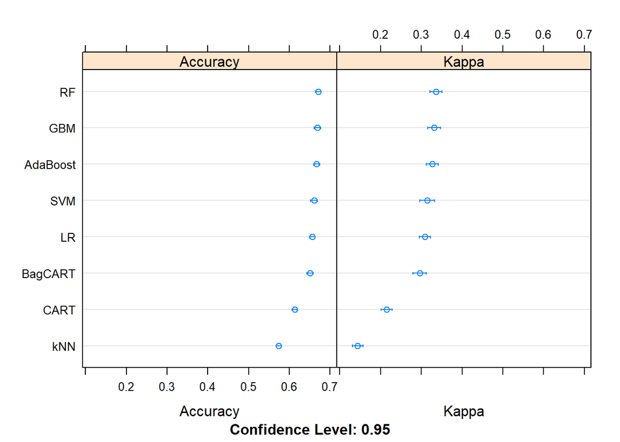

```r
dotplot(results)
```

```r
cat('The average accuracy from all models is:',
    mean(c(results$values$`LR~Accuracy`,results$values$`CART~Accuracy`,results$values$`kNN~Accuracy`,results$values$`SVM~Accuracy`,results$values$`BagCART~Accuracy`,results$values$`RF~Accuracy`,results$values$`AdaBoost~Accuracy`,results$values$`GBM~Accuracy`)))
```

```
## The average accuracy from all models is: 0.645364
```

## 5. Improve Accuracy or Results

After we achieve a short list of machine learning algorithms with good level of accuracy, we can leverage ways to improve the accuracy of the models.

Using the three best-perfoming algorithms from the previous section, we will Search for a combination of parameters for each algorithm that yields the best results.

### 5.a) Algorithm Tuning

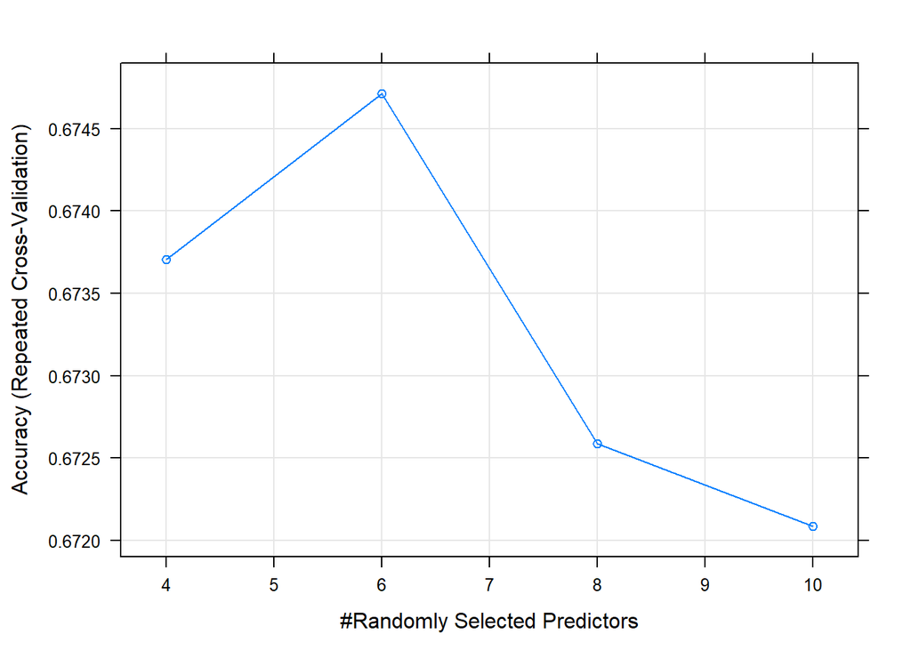

```r
# Tuning algorithm #1 - Random Forest
startTimeModule <- proc.time()
set.seed(seedNum)
grid <- expand.grid(mtry=c(4,6,8,10))
fit.final1 <- train(targetVar~., data=xy_train, method="rf", metric=metricTarget, tuneGrid=grid, trControl=control)
plot(fit.final1)
```

```r
print(fit.final1)
```

```
## Random Forest
##
## 27751 samples
##    58 predictor
##     2 classes: '0', '1'
##
## No pre-processing
## Resampling: Cross-Validated (10 fold, repeated 1 times)
## Summary of sample sizes: 24976, 24976, 24977, 24976, 24976, 24975, ...
## Resampling results across tuning parameters:
##
##   mtry  Accuracy   Kappa
##    4    0.6737054  0.3402453
##    6    0.6747144  0.3426026
##    8    0.6725884  0.3384635
##   10    0.6720839  0.3374981
##
## Accuracy was used to select the optimal model using the largest value.
## The final value used for the model was mtry = 6.
```

```r
proc.time()-startTimeModule
```

```
##    user  system elapsed
## 4251.52   26.21 4280.00
```

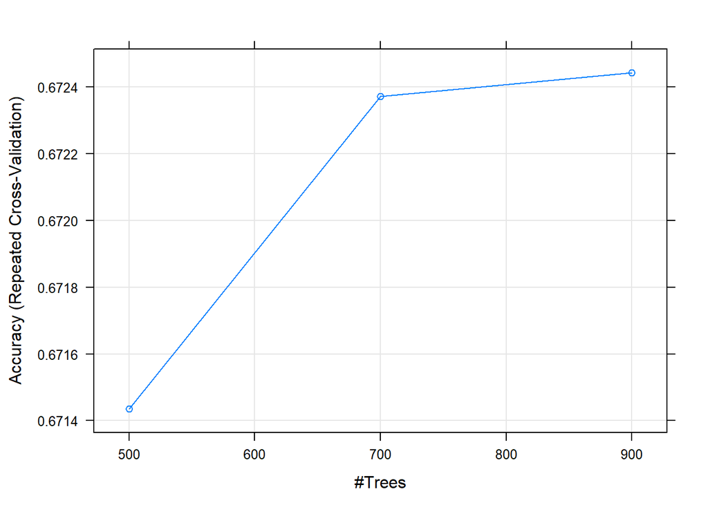

```r
# Tuning algorithm #2 - AdaBoost
startTimeModule <- proc.time()
set.seed(seedNum)
grid <- expand.grid(iter=c(500,700,900), maxdepth=3, nu=0.1)
fit.final2 <- train(targetVar~., data=xy_train, method="ada", metric=metricTarget, tuneGrid=grid, trControl=control)
plot(fit.final2)
```

```r
print(fit.final2)
```

```
## Boosted Classification Trees
##
## 27751 samples
##    58 predictor
##     2 classes: '0', '1'
##
## No pre-processing
## Resampling: Cross-Validated (10 fold, repeated 1 times)
## Summary of sample sizes: 24976, 24976, 24977, 24976, 24976, 24975, ...
## Resampling results across tuning parameters:
##
##   iter  Accuracy   Kappa
##   500   0.6714348  0.3359304
##   700   0.6723719  0.3379633
##   900   0.6724438  0.3382854
##
## Tuning parameter 'maxdepth' was held constant at a value of 3
##
## Tuning parameter 'nu' was held constant at a value of 0.1
## Accuracy was used to select the optimal model using the largest value.
## The final values used for the model were iter = 900, maxdepth = 3 and nu
##  = 0.1.
```

```r
proc.time()-startTimeModule
```

```
##    user  system elapsed
## 3744.25   18.50 3764.40
```

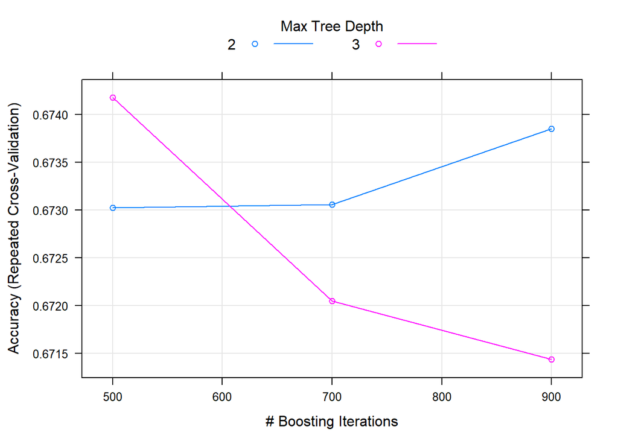

```r
# Tuning algorithm #3 - Stochastic Gradient Boosting
startTimeModule <- proc.time()
set.seed(seedNum)
grid <- expand.grid(.n.trees=c(500,700,900), .shrinkage=0.1, .interaction.depth=c(2,3), .n.minobsinnode=10)
fit.final3 <- train(targetVar~., data=xy_train, method="gbm", metric=metricTarget, tuneGrid=grid, trControl=control, verbose=F)
plot(fit.final3)
```

```r
print(fit.final3)
```

```
## Stochastic Gradient Boosting
##
## 27751 samples
##    58 predictor
##     2 classes: '0', '1'
##
## No pre-processing
## Resampling: Cross-Validated (10 fold, repeated 1 times)
## Summary of sample sizes: 24976, 24976, 24977, 24976, 24976, 24975, ...
## Resampling results across tuning parameters:
##
##   interaction.depth  n.trees  Accuracy   Kappa
##   2                  500      0.6730205  0.3403625
##   2                  700      0.6730563  0.3404114
##   2                  900      0.6738492  0.3421169
##   3                  500      0.6741734  0.3428281
##   3                  700      0.6720477  0.3387053
##   3                  900      0.6714348  0.3373991
##
## Tuning parameter 'shrinkage' was held constant at a value of 0.1
##
## Tuning parameter 'n.minobsinnode' was held constant at a value of 10
## Accuracy was used to select the optimal model using the largest value.
## The final values used for the model were n.trees = 500,
##  interaction.depth = 3, shrinkage = 0.1 and n.minobsinnode = 10.
```

```r
proc.time()-startTimeModule
```

```
##    user  system elapsed
## 1151.28    0.19 1152.00
```

### 5.d) Compare Algorithms After Tuning

```r
results <- resamples(list(RF=fit.final1, ADA=fit.final2, GBM=fit.final3))
summary(results)
```

```
##
## Call:
## summary.resamples(object = results)
##
## Models: RF, ADA, GBM
## Number of resamples: 10
##
## Accuracy
##          Min.   1st Qu.    Median      Mean   3rd Qu.      Max. NA's
## RF  0.6551351 0.6689490 0.6750138 0.6747144 0.6795495 0.6915315    0
## ADA 0.6569369 0.6668766 0.6733920 0.6724438 0.6772973 0.6893694    0
## GBM 0.6582552 0.6712603 0.6748333 0.6741734 0.6783784 0.6918919    0
##
## Kappa
##          Min.   1st Qu.    Median      Mean   3rd Qu.      Max. NA's
## RF  0.3020501 0.3303241 0.3440364 0.3426026 0.3530109 0.3770269    0
## ADA 0.3066848 0.3270618 0.3400803 0.3382854 0.3490052 0.3712419    0
## GBM 0.3091969 0.3371817 0.3444647 0.3428281 0.3524266 0.3788210    0
```

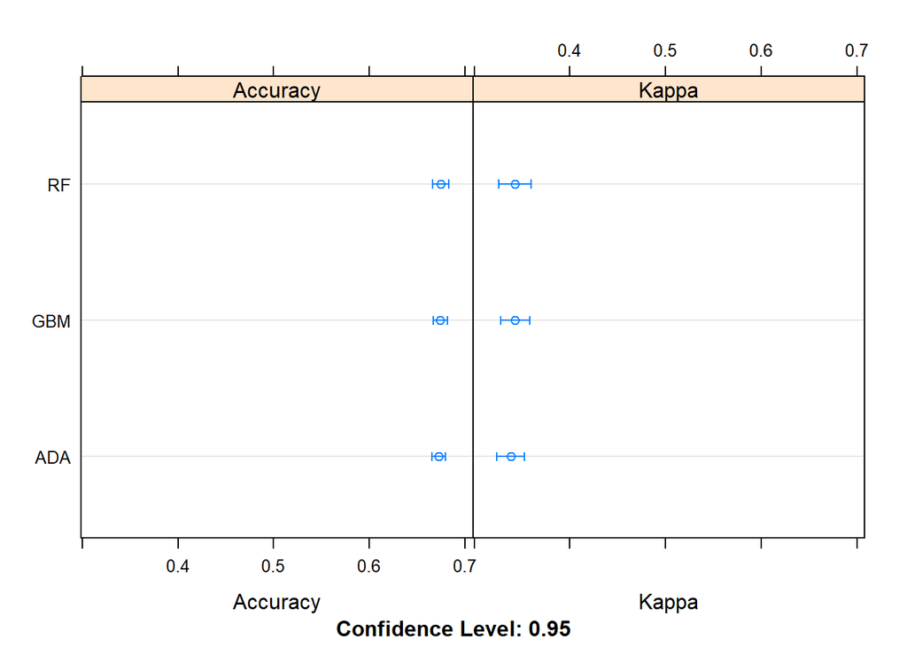

```r
dotplot(results)
```

## 6. Finalize Model and Present Results

Once we have narrow down to a model that we believe can make accurate predictions on unseen data, we are ready to finalize it. Finalizing a model may involve sub-tasks such as:

- Using an optimal model tuned to make predictions on unseen data.
- Creating a standalone model using the tuned parameters
- Saving an optimal model to file for later use.

### 6.a) Predictions on validation dataset

```r
predictions <- predict(fit.final3, newdata=xy_test)
confusionMatrix(predictions, y_test)
```

```
## Confusion Matrix and Statistics
##
##           Reference
## Prediction    0    1
##          0 3396 1811
##          1 2151 4535
##
##                Accuracy : 0.6669
##                  95% CI : (0.6583, 0.6753)
##     No Information Rate : 0.5336
##     P-Value [Acc > NIR] : < 2.2e-16
##
##                   Kappa : 0.3281
##  Mcnemar's Test P-Value : 7.216e-08
##
##             Sensitivity : 0.6122
##             Specificity : 0.7146
##          Pos Pred Value : 0.6522
##          Neg Pred Value : 0.6783
##              Prevalence : 0.4664
##          Detection Rate : 0.2855
##    Detection Prevalence : 0.4378
##       Balanced Accuracy : 0.6634
##
##        'Positive' Class : 0
##
```

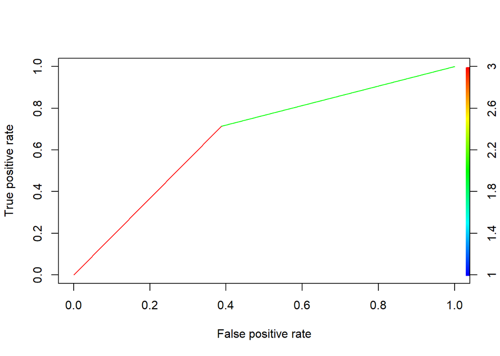

```r
pred <- prediction(as.numeric(predictions), as.numeric(y_test))
perf <- performance(pred, measure = "tpr", x.measure = "fpr")
plot(perf, colorize=TRUE)
```

```r
auc <- performance(pred, measure = "auc")
auc <- auc@y.values[[1]]
auc
```

```
## [1] 0.6634231
```

### 6.b) Create standalone model on entire training dataset

```r
startTimeModule <- proc.time()
library(gbm)
set.seed(seedNum)

# Combining the training and test datasets to form the original dataset that will be used for training the final model
xy_train <- rbind(xy_train, xy_test)

#finalModel <- gbm(targetVar ~ ., data = xy_train, n.trees=700, verbose=F)
grid <- expand.grid(.n.trees=700, .shrinkage=0.1, .interaction.depth=3, .n.minobsinnode=10)
finalModel <- train(targetVar~., data=xy_train, method="gbm", metric=metricTarget, tuneGrid=grid, trControl=control, verbose=F)
print(finalModel)
```

```
## Stochastic Gradient Boosting
##
## 39644 samples
##    58 predictor
##     2 classes: '0', '1'
##
## No pre-processing
## Resampling: Cross-Validated (10 fold, repeated 1 times)
## Summary of sample sizes: 35679, 35679, 35680, 35680, 35680, 35680, ...
## Resampling results:
##
##   Accuracy   Kappa
##   0.6744779  0.3431161
##
## Tuning parameter 'n.trees' was held constant at a value of 700
##  3
## Tuning parameter 'shrinkage' was held constant at a value of 0.1
##
## Tuning parameter 'n.minobsinnode' was held constant at a value of 10
```

```r
proc.time()-startTimeModule
```

```
##    user  system elapsed
##  820.11    0.16  820.58
```

### 6.c) Save model for later use

```r
#saveRDS(finalModel, "./finalModel_BinaryClass.rds")
```

```r
proc.time()-startTimeScript
```

```
##     user   system  elapsed
## 23138.29   274.17 23429.19
```